# First vegetation survey from Woods Lake

Leon Barmuta & Inger Visby

23 December 2015

This is a quick, rough and ready compilation of an .html file, so there will be a few warning messages and other crap appearing in the output.

```
## Warning: NAs introduced by coercion
```

Here are the names and locations of the survey points with vegetation recorded at them. Note that ‘F09’ is the only point that seems to have been missed.

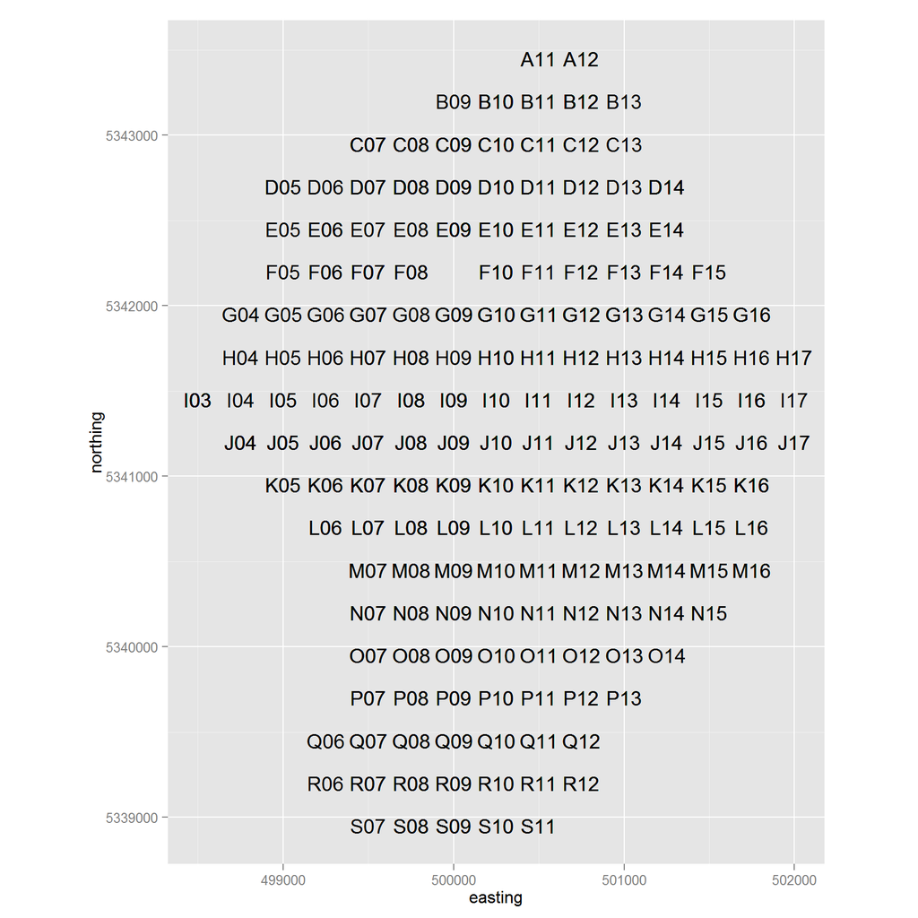

In the following, pink dots denote survey points which get obscured by black dots which are sized according to the (maximum) cover value (%) recorded for that survey point.

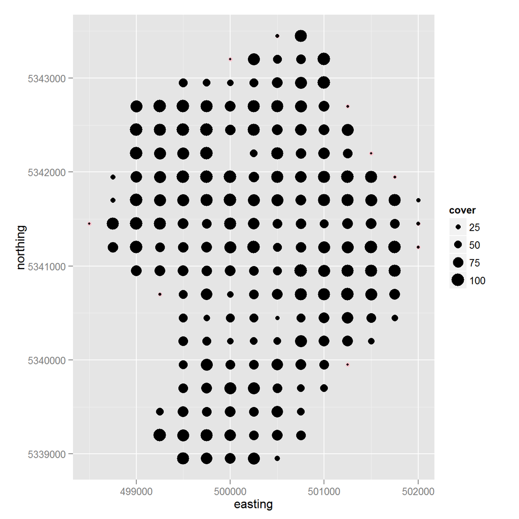

There were only 5 locations with maximum cover < 5%; all were on the edge of the lake at the surveyed time. These are marked in dark olive green in the map below.

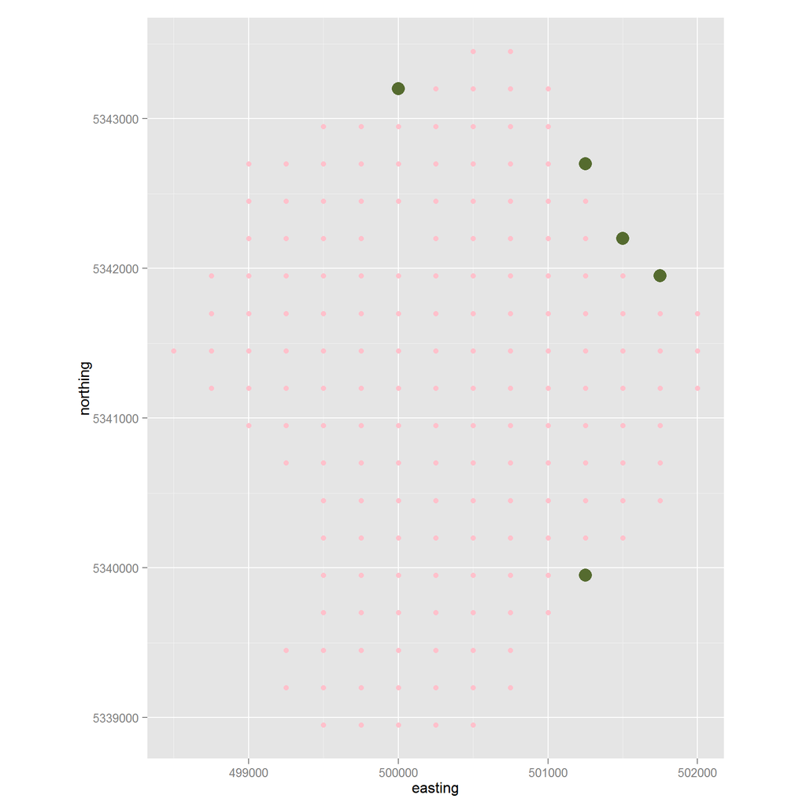

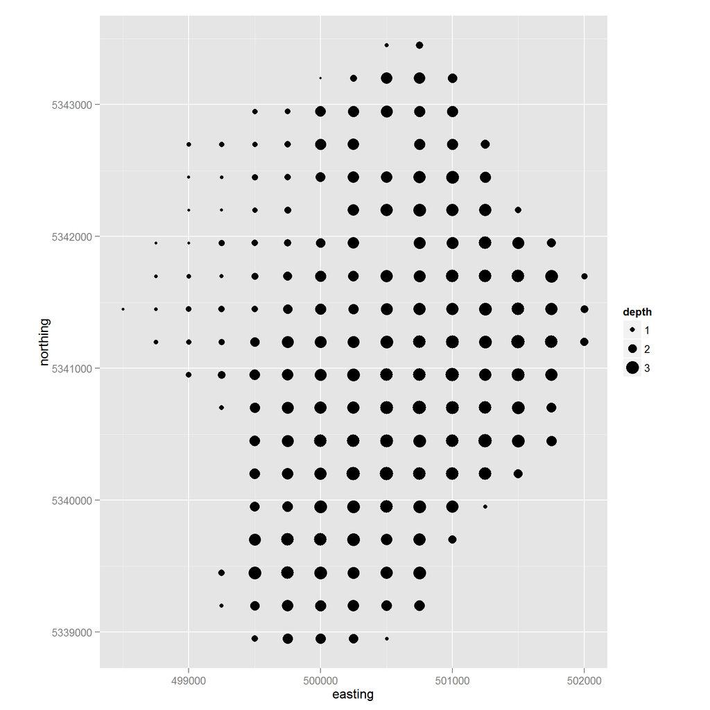

The final map plot is for each species. Size of dot represents percentage cover.

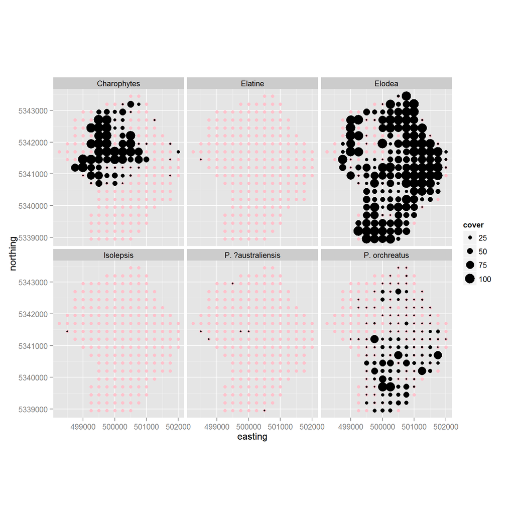

Here is a numerical summary of the vegetation data. Cover of each taxon is recorded as a percentage of projected area of each taxon in the video footage (i.e. in some situations the cover values of all species at a survey point will sum to > 100%). Depth is recorded to within approximately 0.25 m of the sediment surface (the tops of the plants get in the way), so add 0.25 m to those values. There are two missing values for depth, which we could interpolate linearly from adjacent stations.

```
##      depth        Charophytes        Elatine            Elodea         Isolepsis
##  Min.   :0.400   Min.   :  0.00   Min.   :0.00000   Min.   :  0.00   Min.   :0.00000
##  1st Qu.:1.725   1st Qu.:  0.00   1st Qu.:0.00000   1st Qu.: 25.00   1st Qu.:0.00000
##  Median :2.700   Median :  0.00   Median :0.00000   Median : 70.00   Median :0.00000
##  Mean   :2.353   Mean   : 20.78   Mean   :0.01136   Mean   : 58.74   Mean   :0.01136
##  3rd Qu.:3.000   3rd Qu.: 30.00   3rd Qu.:0.00000   3rd Qu.: 90.00   3rd Qu.:0.00000
##  Max.   :3.300   Max.   :100.00   Max.   :2.00000   Max.   :100.00   Max.   :2.00000
##  NA's   :2
##  P. ?australiensis P. orchreatus
##  Min.   :0.00000   Min.   : 0.00
##  1st Qu.:0.00000   1st Qu.: 0.00
##  Median :0.00000   Median : 3.00
##  Mean   :0.05682   Mean   :13.02
##  3rd Qu.:0.00000   3rd Qu.:20.00
##  Max.   :3.00000   Max.   :90.00
##
```

And now for the bivariate plots for the three dominant taxa Loess smoothers superposed to visualise any trends; dots with alpha transparency set so darker dots denote several values superposed at the same plot location.

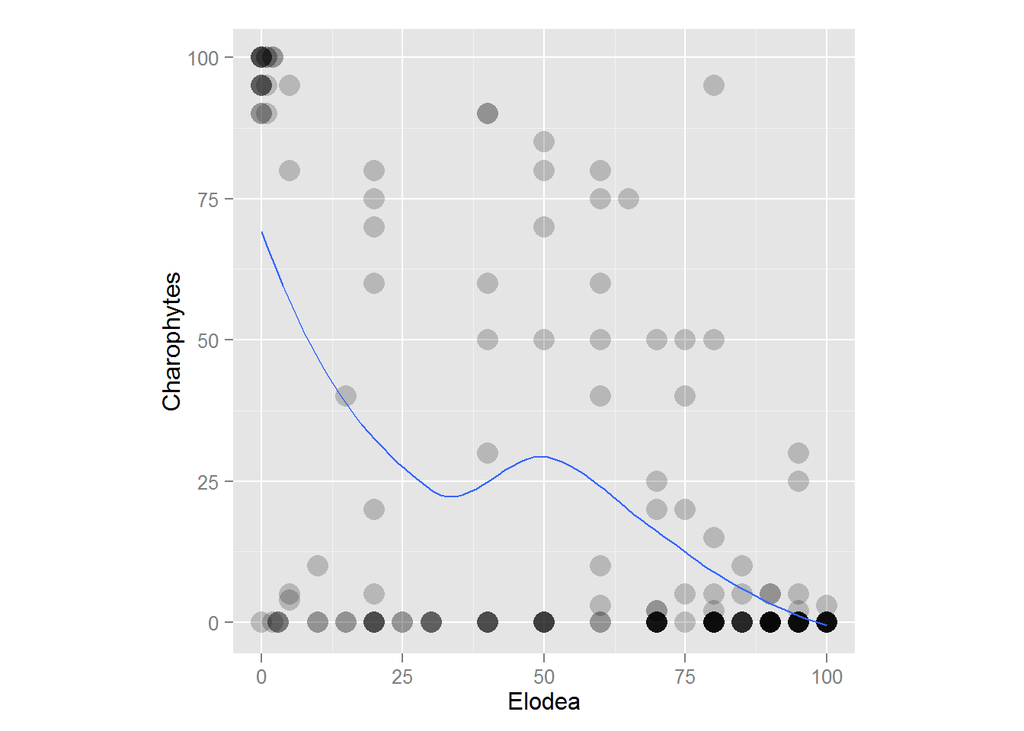

Charophyte cover, when it’s there, tends to be negatively correlated with cover by *Elodea canadensis*.

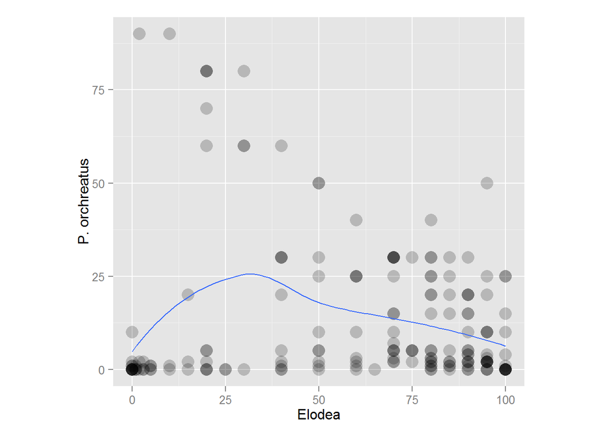

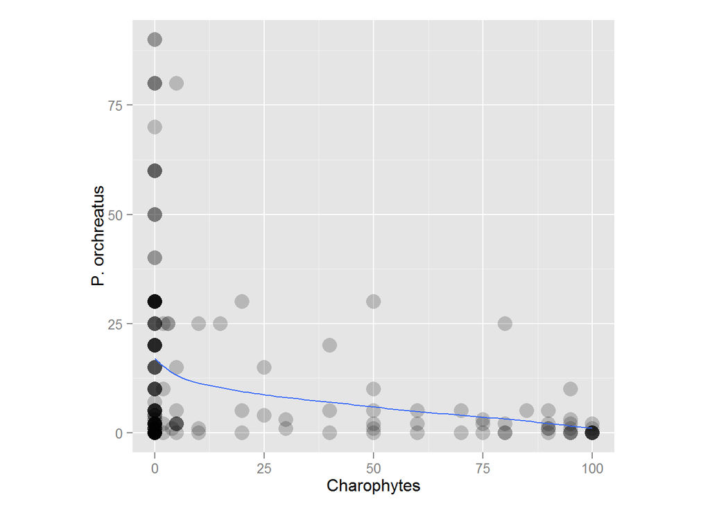

Just for fun, it may interesting to examing percent cover for each taxon versus depth.

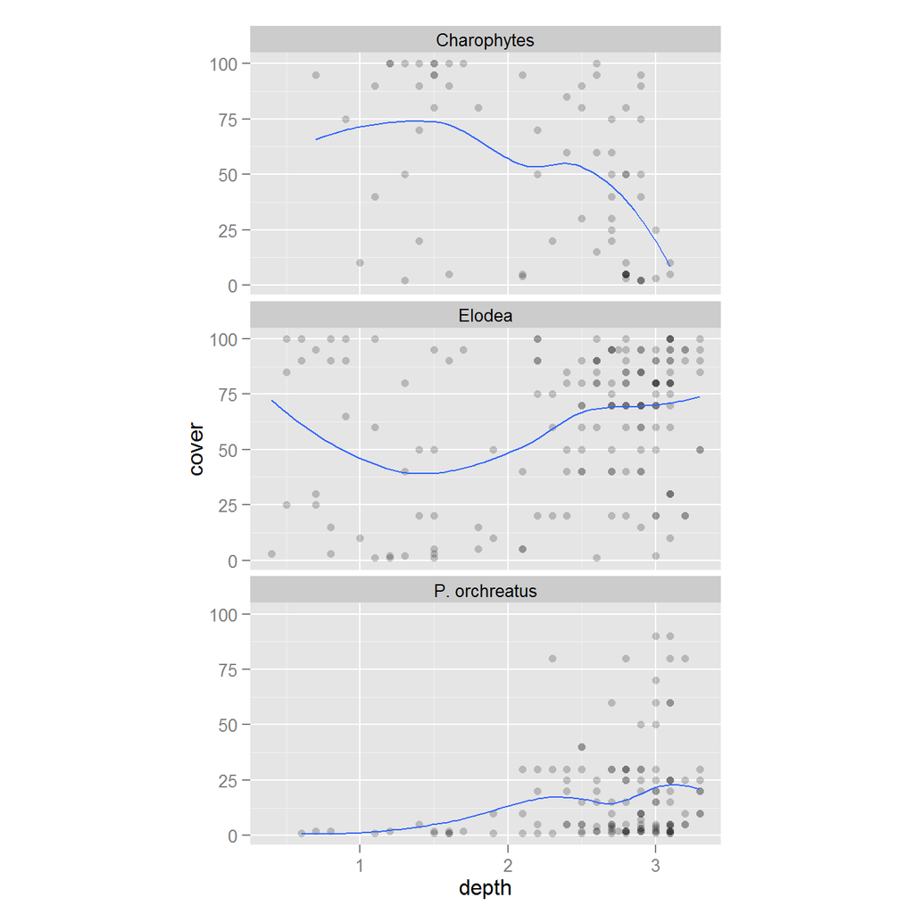